# Introduction to Computational Finance

## Correlation of two series

Let be two normal random variables a1 ∼ N(0, 1) and a2 ∼ N(0, 2^2), generating X = a1 + 2a2 and Y = 2a1 + a2. Using R, one can generate series of X and Y with

```r
set.seed(0);
n=10000;
a1=rnorm(n,mean=0,sd=1);
a2=rnorm(n,mean=0,sd=2);
X=a1+2*a2;
Y=2*a1+a2;
```

- Compute the correlation between X and Y . What is to be expected in terms of X and Y relationship ?

Reminders:  
i) if two random variables are independent, then they are uncorrelated.  
ii) If the correlation coefficient rho is -1, it is a negative correlation, i.e. if X increases then Y decreases. If rho is +1, it is a positive correlation, if X increases then Y also increases. If rho is zero, there is no linear relationship between the two variables.

Given that the two v.a. (random variables) X,Y each take a1 and a2 in their definition, we expect a strong correlation, which is verified: rho~=0.8591

```r
CorelationXY=cov(X,Y)/(sqrt(var(X)*var(Y)));
cat('cor(X,Y)=',CorelationXY)
```

```
## cor(X,Y)= 0.8591271
```

- Draw the graph of realizations of X vs. realizations of Y . Is the slope equal to the correlation coefficient ? Comment on this last point.

No, the slope of the linear regression (~0.59) is not equal to the correlation coefficient (0.85). Here we have $Y = s_1 + Xs_2$, and estimated by least squares, $s_2 = cor(Y_i,X_i) * (SD(Y_i)/SD(X_i))$, so it`s true only if $SD(Y_i)=SD(X_i)$.

```r
relation <- lm(Y~X);
summary(relation)
```

```
##
## Call:
## lm(formula = Y ~ X)
##
## Residuals:
##     Min      1Q  Median      3Q     Max
## -5.5669 -0.9984  0.0014  0.9859  5.0938
##
## Coefficients:
##             Estimate Std. Error t value Pr(>|t|)
## (Intercept) 0.016395   0.014475   1.133    0.257
## X           0.590280   0.003517 167.859   <2e-16 ***
## ---
## Signif. codes:  0 '***' 0.001 '**' 0.01 '*' 0.05 '.' 0.1 ' ' 1
##
## Residual standard error: 1.447 on 9998 degrees of freedom
## Multiple R-squared:  0.7381, Adjusted R-squared:  0.7381
## F-statistic: 2.818e+04 on 1 and 9998 DF,  p-value: < 2.2e-16
```

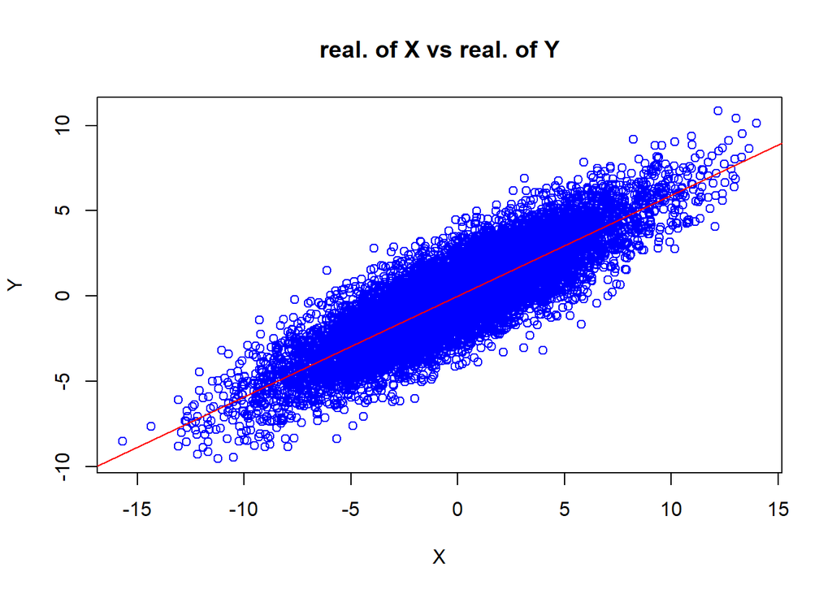

```r
plot(X,Y, col="blue",main="real. of X vs real. of Y")
abline(relation, col="red")
```

## Hidden sine

```r
hiddenSin <- function(T){return(rnorm(100) + sin(2*pi*1:100/T))}
```

- Compute the ACF of the function you saw during the course, which is a sine function to which a gaussian noise is added. Letting T vary, plot the ACF and comment on the impact of T on the ACF ?

Reminder: ACF is an (complete) auto-correlation function which gives us values of auto-correlation of any series with its lagged values (it describes how well the present value of the series is related with its past values).  
If $T1=1$, ie we divide by one, we can’t say anything.

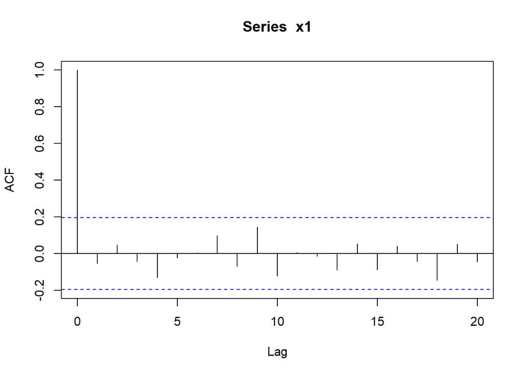

```r
T1=1;
x1 <- hiddenSin(T1)
acf(x1)
```

If we take T=50, it’s interesting because for little lag we have a positive correlation while a negative one for bigger lag, due to sinus wave.

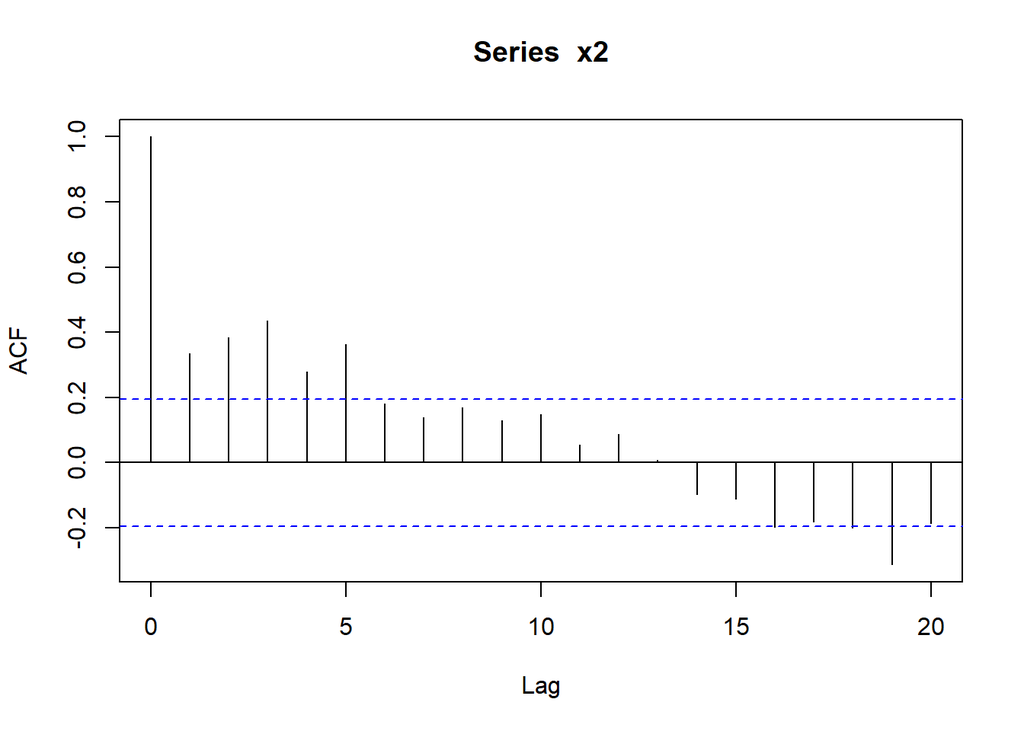

```r
T2=50;
x2 <- hiddenSin(T2)
acf(x2)
```

And if we take T=100, we only have positive correlation because we choose our data in interval [1:100].

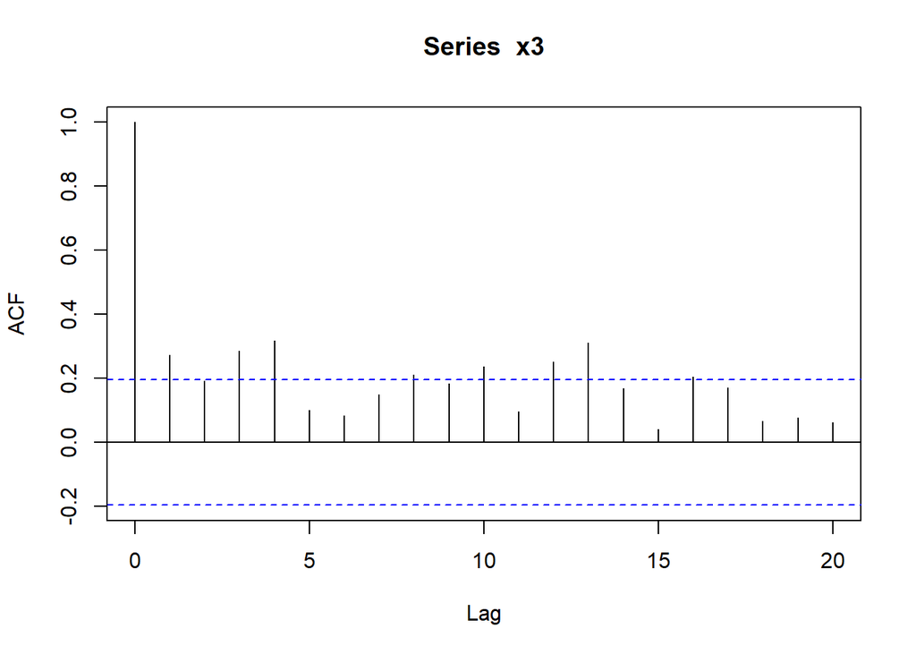

```r
T3=100;
x3 <- hiddenSin(T3)
acf(x3)
```

## Modeling emperical series

*Plot the evolution of the temporal serie. Is it stationary?  
For the evolution of the time series, it is not stationary.

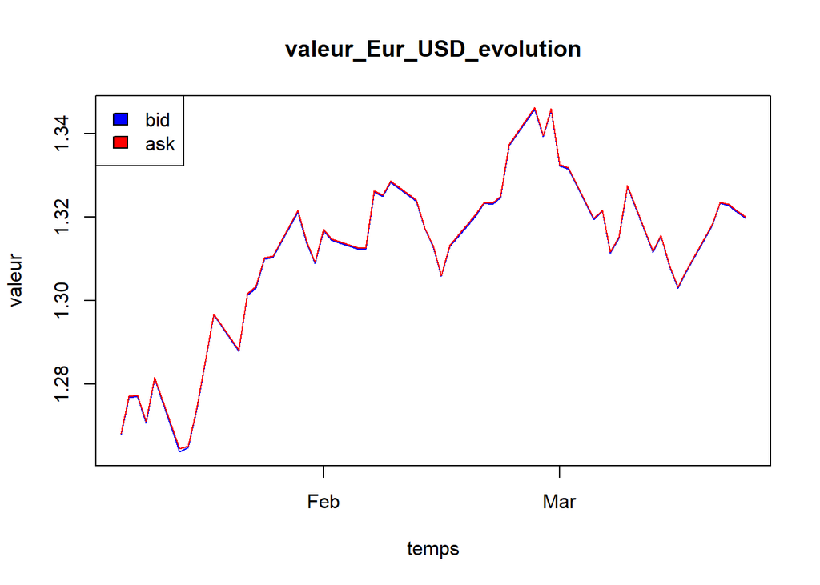

```r
tableau=read.table("priceM.dat");
timeTab=as.POSIXct(tableau[,1]/1000,origin = "1979-01-01");

plot(timeTab,tableau[,2],main="valeur_Eur_USD_evolution", xlab="temps",ylab="valeur",type="l",col="blue")
lines(timeTab,tableau[,3],col="red")
legend("topleft",c("bid","ask"),fill=c("blue","red"))
```

- Plot as well the time evolution of the returns. Is it stationary?  
  For the evolution of returns, it seems to be stationary. To calculate the returns, I calculated : return ~= [(ask_i+bid_i)/2-(ask_i-1+bid_i-1)/2]/((ask_i-1+bid_i-1)/2) because the price of the transaction is between the bid and the ask.

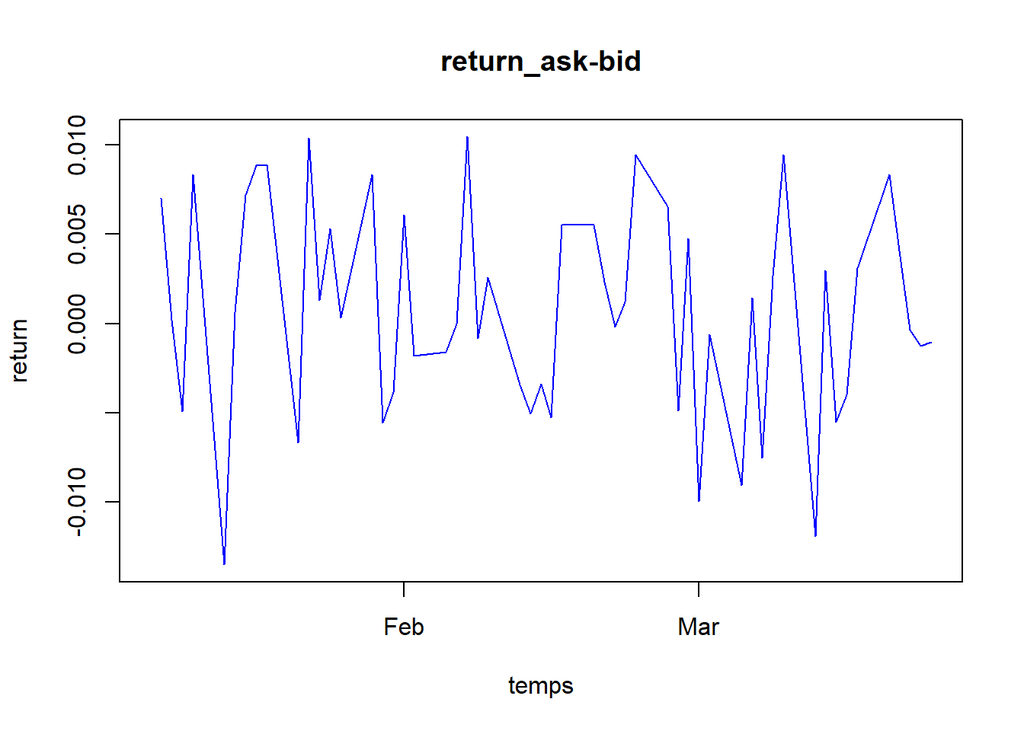

```r
u <- vector(mode="character", length=nrow(tableau));
for (i in 2:nrow(tableau)){#return ~= [(ask_i+bid_i)/2-(ask_i-1+bid_i-1)/2]/((ask_i-1+bid_i-1)/2)
  u[i] <- ( ((tableau[i,3]+tableau[i,2])/2)-(((tableau[i-1,3]+tableau[i-1,2])/2)) ) / ((tableau[i-1,3]+tableau[i-1,2])/2)  ;
}
plot(timeTab,u,main="return_ask-bid",xlab="temps",ylab="return",type="l",col="blue")
```

* Compute and plot the ACF of the stationary serie.

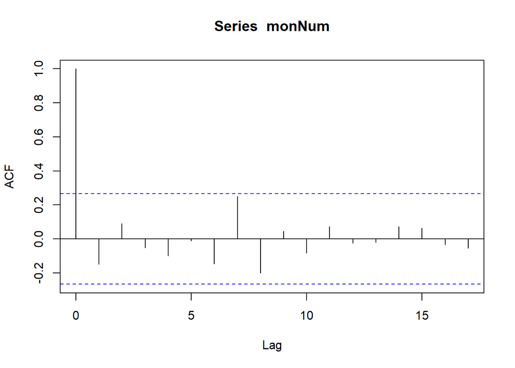

```r
monNum=as.numeric(u[-1])
monACF= acf(monNum)
```

```r
test=ar(monNum, order.max = 1)

x_t0 <- monNum[-1]
x_t1 <- monNum[-length(monNum)]
cat('ordre 1:',cor(x_t0, x_t1),'\n')
```

```
## ordre 1: -0.1516542
```

```r
test2=ar(monNum,order.max=4)
x2_t0 <- monNum[-1]
x2_t1 <- monNum[-length(monNum)]
cat('ordre 4:',cor(x2_t0, x2_t1))
```

```
## ordre 4: -0.1516542
```